# Chicago

Andrea Celleri

# Report

For some time, Chicago has been depicted as one of the most problematic cities in the United States. Some issues facing the city today include increasing crime rates, stagnating economic development and depleting institutional services. These issues many times are linked to the noticeable segregation, specifically between the predominantly white and predominantly black communities. However, how does primarily black populations fair in Chicago when compared with five other cities in the United States? Is it a city issue or a country issue?

Prior to the Fair Housing act of 1968, African Americans could be legally forced to live in separate neighborhoods. The consequences of the policy prior to that time are still visible in cities around the country. To visualize this trend, I plotted the six biggest cities by population in the United States including New York City, Chicago, Los Angeles, Houston, Phoenix, and Philadelphia (“US City Population 2018”). Then I identified census blocks that were dominated by a specific race. If 55 percent of a block belonged to a specific race, it was considered dominated by that race. The results are displayed below.

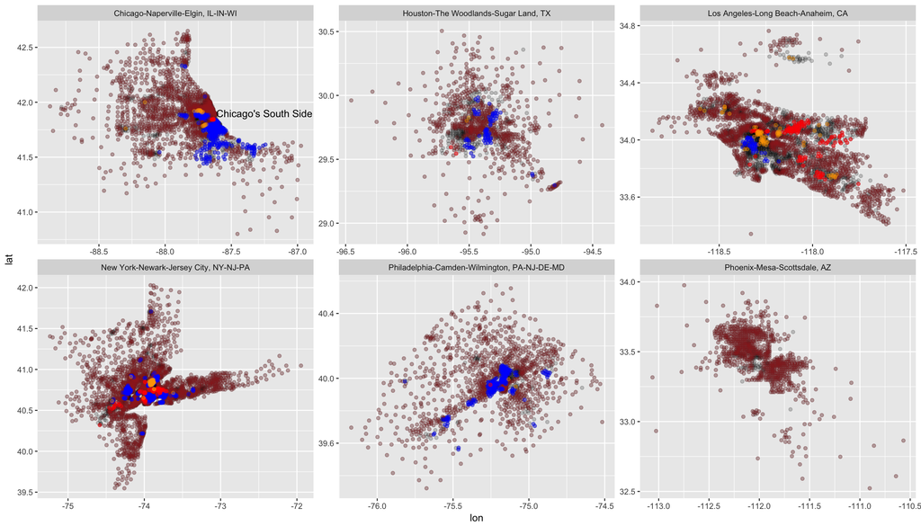

In the graph, each color represents a specific race; blue for the black race, brown for the white race, red for Asian race, and orange for another race. Furthermore, areas in gray represent census blocks that are not dominated by any particular race. As seen, every city except Phoenix has blocks which are dominated by a particular race other than white. Some cities like Los Angeles, have higher populations of Asians as well as Hispanics. Other cities like Philadelphia have been primarily segregated between whites and blacks.

I then looked at two characteristics that are associated with segregation; income and cost of rent. I wanted to compare how racially dominated communities, specifically the black and white communities, faired in comparison with the rest of the city. In Chicago, there are 1936 blocks with a total average of 62 percent white and 21 percent blacks. From the 1936 blocks, there are 1306 blocks that are dominated by whites with a white race mean of 80 percent. On the other hand, there are 337 blocks dominated by blacks with a black race mean of 87 percent. With this in mind, we looked at income earned by the city and the two groups and performed similar comparisons for the other five cities mentioned before.

For this analysis income was divided into three groups; earning between zero and 100 thousand dollars, between 100 and 200 thousand dollars, and between 200 and 999 thousand dollars. In this case, the focus was on the percentage of the population that earned 100 to 200 thousand dollars. The city’s values and the predominantly black and white blocks are plotted against each other below.

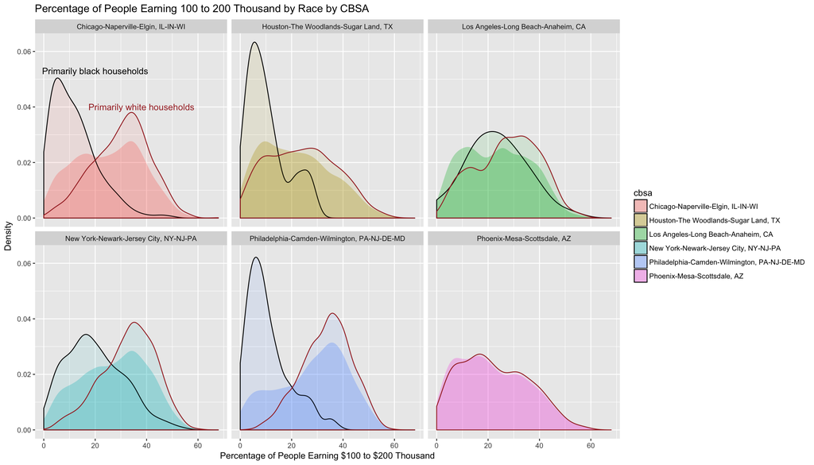

The difference is more prominent when comparing the percentage of households that make between 200 and 999 thousand dollars. Around 10 percent of households in a block in Chicago earn this amount, compared to 14 and 2 percent of white and black blocks respectively.

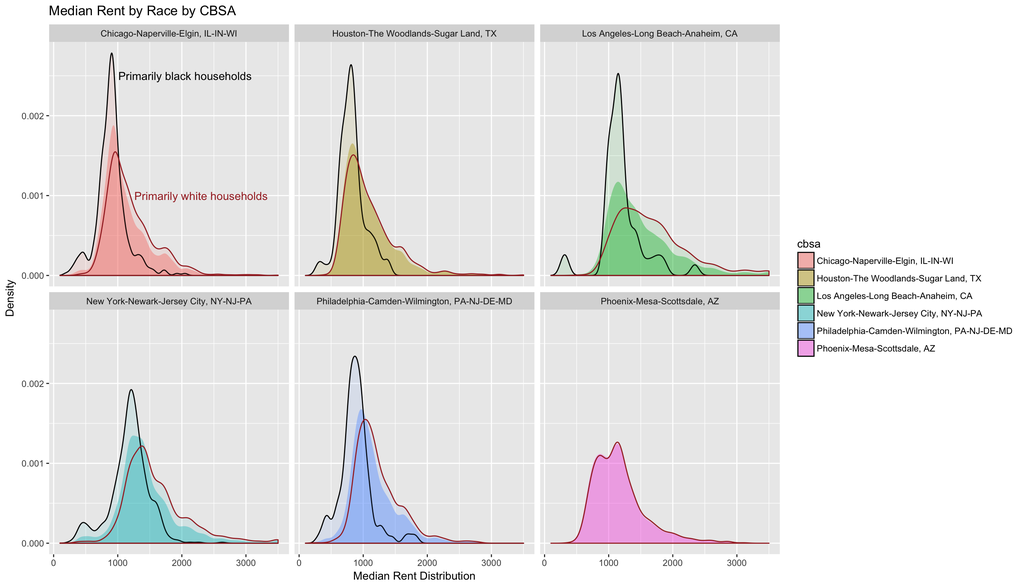

Yes, Chicago is still one of the most segregated cities in the United States. Its segregation has deeper roots than other cities, however, similar patterns can be observed in separate parts of the country. In cases like Los Angeles, where the superficial difference is not as prevalent between whites and blacks, looking at other minorities might provide a different story. Segregation is a complicated problem with no straightforward solution.

## References

Frey, William. “Glimpses of a Ghetto-Free Future.” The New Republic, 26 Nov. 2014, newrepublic.com/article/120385/black-white-segregation-steadily-declining.

“US City Populations 2018.” 2018 World Population by Country, worldpopulationreview.com/us-cities/.